# Optimal Treatment Analysis

## Outcome Variable

**Outcome Variable:** ever_stunted

## Predictor Variables

**Intervention Variable:** mage

**Adjustment Set:**

- arm
- meducyrs
- feducyrs
- W_mhtcm
- single
- delta_meducyrs
- delta_feducyrs
- delta_W_mhtcm
- delta_single

## Stratifying Variables

The analysis was stratified on these variable(s):

- agecat
- studyid
- country

## Data Summary

| agecat | studyid | country | mage | ever_stunted | n_cell | n |
| --- | --- | --- | --- | --- | --- | --- |
| 0-24 months | ki0047075b-MAL-ED | BANGLADESH | [20-30) | 0 | 78 | 265 |
| 0-24 months | ki0047075b-MAL-ED | BANGLADESH | [20-30) | 1 | 104 | 265 |
| 0-24 months | ki0047075b-MAL-ED | BANGLADESH | <20 | 0 | 8 | 265 |
| 0-24 months | ki0047075b-MAL-ED | BANGLADESH | <20 | 1 | 29 | 265 |
| 0-24 months | ki0047075b-MAL-ED | BANGLADESH | >=30 | 0 | 18 | 265 |
| 0-24 months | ki0047075b-MAL-ED | BANGLADESH | >=30 | 1 | 28 | 265 |
| 0-24 months | ki0047075b-MAL-ED | BRAZIL | [20-30) | 0 | 103 | 233 |
| 0-24 months | ki0047075b-MAL-ED | BRAZIL | [20-30) | 1 | 36 | 233 |
| 0-24 months | ki0047075b-MAL-ED | BRAZIL | <20 | 0 | 34 | 233 |
| 0-24 months | ki0047075b-MAL-ED | BRAZIL | <20 | 1 | 9 | 233 |
| 0-24 months | ki0047075b-MAL-ED | BRAZIL | >=30 | 0 | 42 | 233 |
| 0-24 months | ki0047075b-MAL-ED | BRAZIL | >=30 | 1 | 9 | 233 |
| 0-24 months | ki0047075b-MAL-ED | INDIA | [20-30) | 0 | 75 | 249 |
| 0-24 months | ki0047075b-MAL-ED | INDIA | [20-30) | 1 | 119 | 249 |
| 0-24 months | ki0047075b-MAL-ED | INDIA | <20 | 0 | 15 | 249 |
| 0-24 months | ki0047075b-MAL-ED | INDIA | <20 | 1 | 19 | 249 |
| 0-24 months | ki0047075b-MAL-ED | INDIA | >=30 | 0 | 11 | 249 |
| 0-24 months | ki0047075b-MAL-ED | INDIA | >=30 | 1 | 10 | 249 |
| 0-24 months | ki0047075b-MAL-ED | NEPAL | [20-30) | 0 | 127 | 240 |
| 0-24 months | ki0047075b-MAL-ED | NEPAL | [20-30) | 1 | 62 | 240 |
| 0-24 months | ki0047075b-MAL-ED | NEPAL | <20 | 0 | 2 | 240 |
| 0-24 months | ki0047075b-MAL-ED | NEPAL | <20 | 1 | 3 | 240 |
| 0-24 months | ki0047075b-MAL-ED | NEPAL | >=30 | 0 | 28 | 240 |
| 0-24 months | ki0047075b-MAL-ED | NEPAL | >=30 | 1 | 18 | 240 |
| 0-24 months | ki0047075b-MAL-ED | PERU | [20-30) | 0 | 61 | 303 |
| 0-24 months | ki0047075b-MAL-ED | PERU | [20-30) | 1 | 92 | 303 |
| 0-24 months | ki0047075b-MAL-ED | PERU | <20 | 0 | 29 | 303 |
| 0-24 months | ki0047075b-MAL-ED | PERU | <20 | 1 | 54 | 303 |
| 0-24 months | ki0047075b-MAL-ED | PERU | >=30 | 0 | 25 | 303 |
| 0-24 months | ki0047075b-MAL-ED | PERU | >=30 | 1 | 42 | 303 |

[output cut: 450 more lines]

The following strata were considered:

- agecat: 0-24 months, studyid: ki0047075b-MAL-ED, country: BANGLADESH
- agecat: 0-24 months, studyid: ki0047075b-MAL-ED, country: BRAZIL
- agecat: 0-24 months, studyid: ki0047075b-MAL-ED, country: INDIA
- agecat: 0-24 months, studyid: ki0047075b-MAL-ED, country: NEPAL
- agecat: 0-24 months, studyid: ki0047075b-MAL-ED, country: PERU
- agecat: 0-24 months, studyid: ki0047075b-MAL-ED, country: SOUTH AFRICA
- agecat: 0-24 months, studyid: ki0047075b-MAL-ED, country: TANZANIA, UNITED REPUBLIC OF
- agecat: 0-24 months, studyid: ki1000108-CMC-V-BCS-2002, country: INDIA
- agecat: 0-24 months, studyid: ki1000108-IRC, country: INDIA
- agecat: 0-24 months, studyid: ki1000109-EE, country: PAKISTAN
- agecat: 0-24 months, studyid: ki1000304b-SAS-CompFeed, country: INDIA
- agecat: 0-24 months, studyid: ki1000304b-SAS-FoodSuppl, country: INDIA
- agecat: 0-24 months, studyid: ki1017093-NIH-Birth, country: BANGLADESH
- agecat: 0-24 months, studyid: ki1017093b-PROVIDE, country: BANGLADESH
- agecat: 0-24 months, studyid: ki1017093c-NIH-Crypto, country: BANGLADESH
- agecat: 0-24 months, studyid: ki1066203-TanzaniaChild2, country: TANZANIA, UNITED REPUBLIC OF
- agecat: 0-24 months, studyid: ki1101329-Keneba, country: GAMBIA
- agecat: 0-24 months, studyid: ki1112895-Guatemala BSC, country: GUATEMALA
- agecat: 0-24 months, studyid: ki1112895-iLiNS-Zinc, country: BURKINA FASO
- agecat: 0-24 months, studyid: ki1113344-GMS-Nepal, country: NEPAL
- agecat: 0-24 months, studyid: ki1119695-PROBIT, country: BELARUS
- agecat: 0-24 months, studyid: ki1126311-ZVITAMBO, country: ZIMBABWE
- agecat: 0-24 months, studyid: ki1135781-COHORTS, country: GUATEMALA
- agecat: 0-24 months, studyid: ki1135781-COHORTS, country: INDIA
- agecat: 0-24 months, studyid: ki1135781-COHORTS, country: PHILIPPINES
- agecat: 0-24 months, studyid: ki1148112-LCNI-5, country: MALAWI
- agecat: 0-24 months, studyid: kiGH5241-JiVitA-3, country: BANGLADESH
- agecat: 0-6 months, studyid: ki0047075b-MAL-ED, country: BANGLADESH
- agecat: 0-6 months, studyid: ki0047075b-MAL-ED, country: BRAZIL
- agecat: 0-6 months, studyid: ki0047075b-MAL-ED, country: INDIA
- agecat: 0-6 months, studyid: ki0047075b-MAL-ED, country: NEPAL
- agecat: 0-6 months, studyid: ki0047075b-MAL-ED, country: PERU
- agecat: 0-6 months, studyid: ki0047075b-MAL-ED, country: SOUTH AFRICA
- agecat: 0-6 months, studyid: ki0047075b-MAL-ED, country: TANZANIA, UNITED REPUBLIC OF
- agecat: 0-6 months, studyid: ki1000108-CMC-V-BCS-2002, country: INDIA
- agecat: 0-6 months, studyid: ki1000108-IRC, country: INDIA
- agecat: 0-6 months, studyid: ki1000109-EE, country: PAKISTAN
- agecat: 0-6 months, studyid: ki1000304b-SAS-CompFeed, country: INDIA
- agecat: 0-6 months, studyid: ki1000304b-SAS-FoodSuppl, country: INDIA
- agecat: 0-6 months, studyid: ki1017093-NIH-Birth, country: BANGLADESH
- agecat: 0-6 months, studyid: ki1017093b-PROVIDE, country: BANGLADESH
- agecat: 0-6 months, studyid: ki1017093c-NIH-Crypto, country: BANGLADESH
- agecat: 0-6 months, studyid: ki1066203-TanzaniaChild2, country: TANZANIA, UNITED REPUBLIC OF
- agecat: 0-6 months, studyid: ki1101329-Keneba, country: GAMBIA
- agecat: 0-6 months, studyid: ki1112895-Guatemala BSC, country: GUATEMALA
- agecat: 0-6 months, studyid: ki1113344-GMS-Nepal, country: NEPAL
- agecat: 0-6 months, studyid: ki1119695-PROBIT, country: BELARUS
- agecat: 0-6 months, studyid: ki1126311-ZVITAMBO, country: ZIMBABWE
- agecat: 0-6 months, studyid: ki1135781-COHORTS, country: GUATEMALA
- agecat: 0-6 months, studyid: ki1135781-COHORTS, country: INDIA
- agecat: 0-6 months, studyid: ki1135781-COHORTS, country: PHILIPPINES
- agecat: 0-6 months, studyid: ki1148112-LCNI-5, country: MALAWI
- agecat: 0-6 months, studyid: kiGH5241-JiVitA-3, country: BANGLADESH
- agecat: 6-24 months, studyid: ki0047075b-MAL-ED, country: BANGLADESH
- agecat: 6-24 months, studyid: ki0047075b-MAL-ED, country: BRAZIL
- agecat: 6-24 months, studyid: ki0047075b-MAL-ED, country: INDIA
- agecat: 6-24 months, studyid: ki0047075b-MAL-ED, country: NEPAL
- agecat: 6-24 months, studyid: ki0047075b-MAL-ED, country: PERU
- agecat: 6-24 months, studyid: ki0047075b-MAL-ED, country: SOUTH AFRICA
- agecat: 6-24 months, studyid: ki0047075b-MAL-ED, country: TANZANIA, UNITED REPUBLIC OF
- agecat: 6-24 months, studyid: ki1000108-CMC-V-BCS-2002, country: INDIA
- agecat: 6-24 months, studyid: ki1000108-IRC, country: INDIA
- agecat: 6-24 months, studyid: ki1000109-EE, country: PAKISTAN
- agecat: 6-24 months, studyid: ki1000304b-SAS-CompFeed, country: INDIA
- agecat: 6-24 months, studyid: ki1000304b-SAS-FoodSuppl, country: INDIA
- agecat: 6-24 months, studyid: ki1017093-NIH-Birth, country: BANGLADESH
- agecat: 6-24 months, studyid: ki1017093b-PROVIDE, country: BANGLADESH
- agecat: 6-24 months, studyid: ki1017093c-NIH-Crypto, country: BANGLADESH
- agecat: 6-24 months, studyid: ki1066203-TanzaniaChild2, country: TANZANIA, UNITED REPUBLIC OF
- agecat: 6-24 months, studyid: ki1101329-Keneba, country: GAMBIA
- agecat: 6-24 months, studyid: ki1112895-Guatemala BSC, country: GUATEMALA
- agecat: 6-24 months, studyid: ki1112895-iLiNS-Zinc, country: BURKINA FASO
- agecat: 6-24 months, studyid: ki1113344-GMS-Nepal, country: NEPAL
- agecat: 6-24 months, studyid: ki1119695-PROBIT, country: BELARUS
- agecat: 6-24 months, studyid: ki1126311-ZVITAMBO, country: ZIMBABWE
- agecat: 6-24 months, studyid: ki1135781-COHORTS, country: GUATEMALA
- agecat: 6-24 months, studyid: ki1135781-COHORTS, country: INDIA
- agecat: 6-24 months, studyid: ki1135781-COHORTS, country: PHILIPPINES
- agecat: 6-24 months, studyid: ki1148112-LCNI-5, country: MALAWI
- agecat: 6-24 months, studyid: kiGH5241-JiVitA-3, country: BANGLADESH

### Dropped Strata

Some strata were dropped due to rare outcomes:

- agecat: 0-24 months, studyid: ki0047075b-MAL-ED, country: NEPAL
- agecat: 0-24 months, studyid: ki0047075b-MAL-ED, country: TANZANIA, UNITED REPUBLIC OF
- agecat: 0-24 months, studyid: ki1000108-CMC-V-BCS-2002, country: INDIA
- agecat: 0-24 months, studyid: ki1000109-EE, country: PAKISTAN
- agecat: 0-6 months, studyid: ki0047075b-MAL-ED, country: INDIA
- agecat: 0-6 months, studyid: ki0047075b-MAL-ED, country: NEPAL
- agecat: 0-6 months, studyid: ki0047075b-MAL-ED, country: TANZANIA, UNITED REPUBLIC OF
- agecat: 0-6 months, studyid: ki1000109-EE, country: PAKISTAN
- agecat: 6-24 months, studyid: ki0047075b-MAL-ED, country: BRAZIL
- agecat: 6-24 months, studyid: ki0047075b-MAL-ED, country: NEPAL
- agecat: 6-24 months, studyid: ki0047075b-MAL-ED, country: TANZANIA, UNITED REPUBLIC OF
- agecat: 6-24 months, studyid: ki1000108-CMC-V-BCS-2002, country: INDIA
- agecat: 6-24 months, studyid: ki1000108-IRC, country: INDIA
- agecat: 6-24 months, studyid: ki1000109-EE, country: PAKISTAN

## Methods Detail

We’re interested in the causal parameters $E[Y_a]$ for all values of $a \in \mathcal{A}$. These parameters represent the mean outcome if, possibly contrary to fact, we intervened to set all units to have $A=a$. Under the randomization and positivity assumptions, these are identified by the statistical parameters $\psi_a=E_W[E_{Y|A,W}(Y|A=a,W)]$. In addition, we’re interested in the mean of $Y$, $E[Y]$ under no intervention (the observed mean). We will estimate these parameters by using SuperLearner to fit the relevant likelihood factors – $E_{Y|A,W}(Y|A=a,W)$ and $p(A=a|W)$, and then updating our likelihood fit using a joint TMLE.

For unadjusted analyses ($W=\{\}$), initial likelihoods were estimated using Lrnr_glm to estimate the simple $E(Y|A)$ and Lrnr_mean to estimate $p(A)$. For adjusted analyses, a small library containing Lrnr_glmnet, Lrnr_xgboost, and Lrnr_mean was used.

Having estimated these parameters, we will then use the delta method to estimate relative risks and attributable risks relative to a prespecified baseline level of $A$.

# Results Detail

## Results Plots

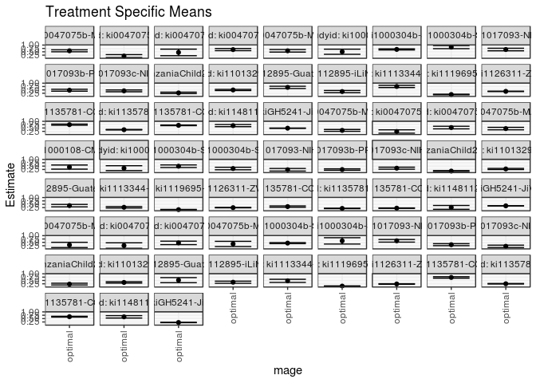

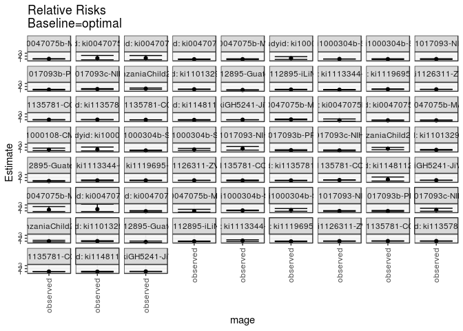

## Results Table

### Parameter: TSM

| agecat | studyid | country | intervention_level | baseline_level | estimate | ci_lower | ci_upper |
| --- | --- | --- | --- | --- | --- | --- | --- |
| 0-24 months | ki0047075b-MAL-ED | BANGLADESH | optimal | NA | 0.5725251 | 0.5002710 | 0.6447792 |
| 0-24 months | ki0047075b-MAL-ED | BRAZIL | optimal | NA | 0.1804301 | 0.0708936 | 0.2899665 |
| 0-24 months | ki0047075b-MAL-ED | INDIA | optimal | NA | 0.4521229 | 0.2082412 | 0.6960047 |
| 0-24 months | ki0047075b-MAL-ED | PERU | optimal | NA | 0.6626084 | 0.5827084 | 0.7425084 |
| 0-24 months | ki0047075b-MAL-ED | SOUTH AFRICA | optimal | NA | 0.5718129 | 0.4778392 | 0.6657865 |
| 0-24 months | ki1000108-IRC | INDIA | optimal | NA | 0.5031404 | 0.3119476 | 0.6943332 |
| 0-24 months | ki1000304b-SAS-CompFeed | INDIA | optimal | NA | 0.6765972 | 0.6329778 | 0.7202165 |
| 0-24 months | ki1000304b-SAS-FoodSuppl | INDIA | optimal | NA | 0.8486946 | 0.7323069 | 0.9650822 |
| 0-24 months | ki1017093-NIH-Birth | BANGLADESH | optimal | NA | 0.6678923 | 0.5724248 | 0.7633597 |
| 0-24 months | ki1017093b-PROVIDE | BANGLADESH | optimal | NA | 0.4741894 | 0.4043196 | 0.5440591 |
| 0-24 months | ki1017093c-NIH-Crypto | BANGLADESH | optimal | NA | 0.4281081 | 0.3607911 | 0.4954251 |
| 0-24 months | ki1066203-TanzaniaChild2 | TANZANIA, UNITED REPUBLIC OF | optimal | NA | 0.2764453 | 0.2237610 | 0.3291297 |
| 0-24 months | ki1101329-Keneba | GAMBIA | optimal | NA | 0.4952452 | 0.4525634 | 0.5379270 |
| 0-24 months | ki1112895-Guatemala BSC | GUATEMALA | optimal | NA | 0.6883015 | 0.6045674 | 0.7720356 |
| 0-24 months | ki1112895-iLiNS-Zinc | BURKINA FASO | optimal | NA | 0.3757366 | 0.2937238 | 0.4577495 |
| 0-24 months | ki1113344-GMS-Nepal | NEPAL | optimal | NA | 0.7566708 | 0.6733019 | 0.8400396 |
| 0-24 months | ki1119695-PROBIT | BELARUS | optimal | NA | 0.1567195 | 0.1348399 | 0.1785991 |
| 0-24 months | ki1126311-ZVITAMBO | ZIMBABWE | optimal | NA | 0.3909710 | 0.3746261 | 0.4073158 |
| 0-24 months | ki1135781-COHORTS | GUATEMALA | optimal | NA | 0.7493929 | 0.7062140 | 0.7925719 |
| 0-24 months | ki1135781-COHORTS | INDIA | optimal | NA | 0.3728386 | 0.3554502 | 0.3902271 |
| 0-24 months | ki1135781-COHORTS | PHILIPPINES | optimal | NA | 0.6997683 | 0.6735583 | 0.7259784 |
| 0-24 months | ki1148112-LCNI-5 | MALAWI | optimal | NA | 0.6789781 | 0.6008262 | 0.7571299 |
| 0-24 months | kiGH5241-JiVitA-3 | BANGLADESH | optimal | NA | 0.4861267 | 0.4729446 | 0.4993088 |
| 0-6 months | ki0047075b-MAL-ED | BANGLADESH | optimal | NA | 0.3232134 | 0.2551412 | 0.3912856 |
| 0-6 months | ki0047075b-MAL-ED | BRAZIL | optimal | NA | 0.2401679 | 0.1150330 | 0.3653029 |
| 0-6 months | ki0047075b-MAL-ED | PERU | optimal | NA | 0.5334378 | 0.4353303 | 0.6315453 |
| 0-6 months | ki0047075b-MAL-ED | SOUTH AFRICA | optimal | NA | 0.4569407 | 0.3644601 | 0.5494213 |
| 0-6 months | ki1000108-CMC-V-BCS-2002 | INDIA | optimal | NA | 0.4289969 | 0.2741037 | 0.5838902 |
| 0-6 months | ki1000108-IRC | INDIA | optimal | NA | 0.3459395 | 0.1627625 | 0.5291164 |
| 0-6 months | ki1000304b-SAS-CompFeed | INDIA | optimal | NA | 0.4929324 | 0.3957431 | 0.5901216 |
| 0-6 months | ki1000304b-SAS-FoodSuppl | INDIA | optimal | NA | 0.3216174 | 0.2282657 | 0.4149690 |
| 0-6 months | ki1017093-NIH-Birth | BANGLADESH | optimal | NA | 0.2312391 | 0.1344777 | 0.3280005 |
| 0-6 months | ki1017093b-PROVIDE | BANGLADESH | optimal | NA | 0.2463367 | 0.1941438 | 0.2985295 |
| 0-6 months | ki1017093c-NIH-Crypto | BANGLADESH | optimal | NA | 0.3444538 | 0.2675743 | 0.4213333 |
| 0-6 months | ki1066203-TanzaniaChild2 | TANZANIA, UNITED REPUBLIC OF | optimal | NA | 0.1301265 | 0.0931622 | 0.1670909 |
| 0-6 months | ki1101329-Keneba | GAMBIA | optimal | NA | 0.2897339 | 0.2469772 | 0.3324906 |
| 0-6 months | ki1112895-Guatemala BSC | GUATEMALA | optimal | NA | 0.3970735 | 0.3056975 | 0.4884495 |
| 0-6 months | ki1113344-GMS-Nepal | NEPAL | optimal | NA | 0.2741781 | 0.2191816 | 0.3291746 |
| 0-6 months | ki1119695-PROBIT | BELARUS | optimal | NA | 0.0969021 | 0.0801656 | 0.1136386 |
| 0-6 months | ki1126311-ZVITAMBO | ZIMBABWE | optimal | NA | 0.2473692 | 0.2321375 | 0.2626009 |
| 0-6 months | ki1135781-COHORTS | GUATEMALA | optimal | NA | 0.3243335 | 0.2715288 | 0.3771381 |
| 0-6 months | ki1135781-COHORTS | INDIA | optimal | NA | 0.1903802 | 0.1725391 | 0.2082213 |
| 0-6 months | ki1135781-COHORTS | PHILIPPINES | optimal | NA | 0.2090021 | 0.1904198 | 0.2275843 |
| 0-6 months | ki1148112-LCNI-5 | MALAWI | optimal | NA | 0.2664818 | 0.1235426 | 0.4094209 |
| 0-6 months | kiGH5241-JiVitA-3 | BANGLADESH | optimal | NA | 0.3815026 | 0.3690669 | 0.3939382 |
| 6-24 months | ki0047075b-MAL-ED | BANGLADESH | optimal | NA | 0.3091911 | 0.1134504 | 0.5049318 |
| 6-24 months | ki0047075b-MAL-ED | INDIA | optimal | NA | 0.2621541 | 0.0588674 | 0.4654408 |
| 6-24 months | ki0047075b-MAL-ED | PERU | optimal | NA | 0.4608978 | 0.3324122 | 0.5893834 |
| 6-24 months | ki0047075b-MAL-ED | SOUTH AFRICA | optimal | NA | 0.3844362 | 0.1900439 | 0.5788285 |
| 6-24 months | ki1000304b-SAS-CompFeed | INDIA | optimal | NA | 0.4447805 | 0.4044336 | 0.4851273 |
| 6-24 months | ki1000304b-SAS-FoodSuppl | INDIA | optimal | NA | 0.6113089 | 0.3752706 | 0.8473473 |
| 6-24 months | ki1017093-NIH-Birth | BANGLADESH | optimal | NA | 0.6162208 | 0.5172870 | 0.7151547 |
| 6-24 months | ki1017093b-PROVIDE | BANGLADESH | optimal | NA | 0.3264009 | 0.2519800 | 0.4008218 |
| 6-24 months | ki1017093c-NIH-Crypto | BANGLADESH | optimal | NA | 0.2061437 | 0.1186498 | 0.2936377 |
| 6-24 months | ki1066203-TanzaniaChild2 | TANZANIA, UNITED REPUBLIC OF | optimal | NA | 0.2282427 | 0.1630539 | 0.2934315 |
| 6-24 months | ki1101329-Keneba | GAMBIA | optimal | NA | 0.3550692 | 0.3026239 | 0.4075145 |
| 6-24 months | ki1112895-Guatemala BSC | GUATEMALA | optimal | NA | 0.5261456 | 0.3390025 | 0.7132887 |
| 6-24 months | ki1112895-iLiNS-Zinc | BURKINA FASO | optimal | NA | 0.3695816 | 0.2907833 | 0.4483798 |
| 6-24 months | ki1113344-GMS-Nepal | NEPAL | optimal | NA | 0.4734265 | 0.3567868 | 0.5900663 |
| 6-24 months | ki1119695-PROBIT | BELARUS | optimal | NA | 0.0814930 | 0.0684804 | 0.0945057 |
| 6-24 months | ki1126311-ZVITAMBO | ZIMBABWE | optimal | NA | 0.2397303 | 0.2215592 | 0.2579013 |
| 6-24 months | ki1135781-COHORTS | GUATEMALA | optimal | NA | 0.7256811 | 0.6711141 | 0.7802481 |
| 6-24 months | ki1135781-COHORTS | INDIA | optimal | NA | 0.2548145 | 0.2359025 | 0.2737264 |
| 6-24 months | ki1135781-COHORTS | PHILIPPINES | optimal | NA | 0.6414031 | 0.6119395 | 0.6708668 |
| 6-24 months | ki1148112-LCNI-5 | MALAWI | optimal | NA | 0.6302121 | 0.5404936 | 0.7199307 |
| 6-24 months | kiGH5241-JiVitA-3 | BANGLADESH | optimal | NA | 0.2099182 | 0.1966876 | 0.2231488 |

### Parameter: E(Y)

| agecat | studyid | country | intervention_level | baseline_level | estimate | ci_lower | ci_upper |
| --- | --- | --- | --- | --- | --- | --- | --- |
| 0-24 months | ki0047075b-MAL-ED | BANGLADESH | observed | NA | 0.6075472 | 0.5486452 | 0.6664491 |
| 0-24 months | ki0047075b-MAL-ED | BRAZIL | observed | NA | 0.2317597 | 0.1774632 | 0.2860561 |
| 0-24 months | ki0047075b-MAL-ED | INDIA | observed | NA | 0.5943775 | 0.5332672 | 0.6554878 |
| 0-24 months | ki0047075b-MAL-ED | PERU | observed | NA | 0.6204620 | 0.5657315 | 0.6751926 |
| 0-24 months | ki0047075b-MAL-ED | SOUTH AFRICA | observed | NA | 0.5445860 | 0.4894148 | 0.5997572 |
| 0-24 months | ki1000108-IRC | INDIA | observed | NA | 0.6414634 | 0.5949863 | 0.6879405 |
| 0-24 months | ki1000304b-SAS-CompFeed | INDIA | observed | NA | 0.6914547 | 0.6510509 | 0.7318584 |
| 0-24 months | ki1000304b-SAS-FoodSuppl | INDIA | observed | NA | 0.8277512 | 0.7915095 | 0.8639929 |
| 0-24 months | ki1017093-NIH-Birth | BANGLADESH | observed | NA | 0.6634769 | 0.6264616 | 0.7004922 |
| 0-24 months | ki1017093b-PROVIDE | BANGLADESH | observed | NA | 0.4342857 | 0.3975409 | 0.4710305 |
| 0-24 months | ki1017093c-NIH-Crypto | BANGLADESH | observed | NA | 0.4775726 | 0.4419904 | 0.5131548 |
| 0-24 months | ki1066203-TanzaniaChild2 | TANZANIA, UNITED REPUBLIC OF | observed | NA | 0.3459596 | 0.3268289 | 0.3650903 |
| 0-24 months | ki1101329-Keneba | GAMBIA | observed | NA | 0.5183631 | 0.5000444 | 0.5366817 |
| 0-24 months | ki1112895-Guatemala BSC | GUATEMALA | observed | NA | 0.5551601 | 0.4969525 | 0.6133678 |
| 0-24 months | ki1112895-iLiNS-Zinc | BURKINA FASO | observed | NA | 0.3559962 | 0.3060347 | 0.4059578 |
| 0-24 months | ki1113344-GMS-Nepal | NEPAL | observed | NA | 0.6744186 | 0.6369554 | 0.7118819 |
| 0-24 months | ki1119695-PROBIT | BELARUS | observed | NA | 0.1674854 | 0.1488048 | 0.1861659 |
| 0-24 months | ki1126311-ZVITAMBO | ZIMBABWE | observed | NA | 0.3966365 | 0.3885423 | 0.4047307 |
| 0-24 months | ki1135781-COHORTS | GUATEMALA | observed | NA | 0.7639706 | 0.7413939 | 0.7865473 |
| 0-24 months | ki1135781-COHORTS | INDIA | observed | NA | 0.3877282 | 0.3746257 | 0.4008307 |
| 0-24 months | ki1135781-COHORTS | PHILIPPINES | observed | NA | 0.6863963 | 0.6699497 | 0.7028430 |
| 0-24 months | ki1148112-LCNI-5 | MALAWI | observed | NA | 0.6373134 | 0.6008819 | 0.6737450 |
| 0-24 months | kiGH5241-JiVitA-3 | BANGLADESH | observed | NA | 0.4937741 | 0.4859396 | 0.5016087 |
| 0-6 months | ki0047075b-MAL-ED | BANGLADESH | observed | NA | 0.3547170 | 0.2970055 | 0.4124285 |
| 0-6 months | ki0047075b-MAL-ED | BRAZIL | observed | NA | 0.1931330 | 0.1423366 | 0.2439295 |
| 0-6 months | ki0047075b-MAL-ED | PERU | observed | NA | 0.4257426 | 0.3699763 | 0.4815088 |
| 0-6 months | ki0047075b-MAL-ED | SOUTH AFRICA | observed | NA | 0.3598726 | 0.3067005 | 0.4130447 |
| 0-6 months | ki1000108-CMC-V-BCS-2002 | INDIA | observed | NA | 0.5108696 | 0.4597270 | 0.5620121 |
| 0-6 months | ki1000108-IRC | INDIA | observed | NA | 0.4243902 | 0.3764905 | 0.4722900 |
| 0-6 months | ki1000304b-SAS-CompFeed | INDIA | observed | NA | 0.4254902 | 0.3977202 | 0.4532601 |
| 0-6 months | ki1000304b-SAS-FoodSuppl | INDIA | observed | NA | 0.3894231 | 0.3425088 | 0.4363374 |
| 0-6 months | ki1017093-NIH-Birth | BANGLADESH | observed | NA | 0.3476874 | 0.3103810 | 0.3849938 |
| 0-6 months | ki1017093b-PROVIDE | BANGLADESH | observed | NA | 0.2385714 | 0.2069753 | 0.2701675 |
| 0-6 months | ki1017093c-NIH-Crypto | BANGLADESH | observed | NA | 0.3021108 | 0.2694011 | 0.3348205 |
| 0-6 months | ki1066203-TanzaniaChild2 | TANZANIA, UNITED REPUBLIC OF | observed | NA | 0.1944444 | 0.1785274 | 0.2103615 |
| 0-6 months | ki1101329-Keneba | GAMBIA | observed | NA | 0.3127302 | 0.2943427 | 0.3311178 |
| 0-6 months | ki1112895-Guatemala BSC | GUATEMALA | observed | NA | 0.3181818 | 0.2618904 | 0.3744732 |
| 0-6 months | ki1113344-GMS-Nepal | NEPAL | observed | NA | 0.2774086 | 0.2416141 | 0.3132032 |
| 0-6 months | ki1119695-PROBIT | BELARUS | observed | NA | 0.0995087 | 0.0864641 | 0.1125533 |
| 0-6 months | ki1126311-ZVITAMBO | ZIMBABWE | observed | NA | 0.2580829 | 0.2508371 | 0.2653287 |
| 0-6 months | ki1135781-COHORTS | GUATEMALA | observed | NA | 0.3253896 | 0.2975756 | 0.3532035 |
| 0-6 months | ki1135781-COHORTS | INDIA | observed | NA | 0.1902629 | 0.1795262 | 0.2009996 |
| 0-6 months | ki1135781-COHORTS | PHILIPPINES | observed | NA | 0.2390451 | 0.2239262 | 0.2541640 |
| 0-6 months | ki1148112-LCNI-5 | MALAWI | observed | NA | 0.3545455 | 0.2911884 | 0.4179025 |
| 0-6 months | kiGH5241-JiVitA-3 | BANGLADESH | observed | NA | 0.4107662 | 0.4033277 | 0.4182048 |
| 6-24 months | ki0047075b-MAL-ED | BANGLADESH | observed | NA | 0.4213836 | 0.3443902 | 0.4983771 |
| 6-24 months | ki0047075b-MAL-ED | INDIA | observed | NA | 0.4129032 | 0.3351414 | 0.4906651 |
| 6-24 months | ki0047075b-MAL-ED | PERU | observed | NA | 0.3959732 | 0.3171819 | 0.4747644 |
| 6-24 months | ki0047075b-MAL-ED | SOUTH AFRICA | observed | NA | 0.3647799 | 0.2897219 | 0.4398379 |
| 6-24 months | ki1000304b-SAS-CompFeed | INDIA | observed | NA | 0.5030750 | 0.4588491 | 0.5473009 |
| 6-24 months | ki1000304b-SAS-FoodSuppl | INDIA | observed | NA | 0.7572016 | 0.7031798 | 0.8112234 |
| 6-24 months | ki1017093-NIH-Birth | BANGLADESH | observed | NA | 0.5739130 | 0.5216565 | 0.6261696 |
| 6-24 months | ki1017093b-PROVIDE | BANGLADESH | observed | NA | 0.2997812 | 0.2577294 | 0.3418330 |
| 6-24 months | ki1017093c-NIH-Crypto | BANGLADESH | observed | NA | 0.2628458 | 0.2244546 | 0.3012371 |
| 6-24 months | ki1066203-TanzaniaChild2 | TANZANIA, UNITED REPUBLIC OF | observed | NA | 0.2262728 | 0.2057063 | 0.2468392 |
| 6-24 months | ki1101329-Keneba | GAMBIA | observed | NA | 0.3640974 | 0.3428547 | 0.3853400 |
| 6-24 months | ki1112895-Guatemala BSC | GUATEMALA | observed | NA | 0.3913043 | 0.3205945 | 0.4620142 |
| 6-24 months | ki1112895-iLiNS-Zinc | BURKINA FASO | observed | NA | 0.3559962 | 0.3060347 | 0.4059578 |
| 6-24 months | ki1113344-GMS-Nepal | NEPAL | observed | NA | 0.5610329 | 0.5138522 | 0.6082135 |
| 6-24 months | ki1119695-PROBIT | BELARUS | observed | NA | 0.0768510 | 0.0628857 | 0.0908164 |
| 6-24 months | ki1126311-ZVITAMBO | ZIMBABWE | observed | NA | 0.2456848 | 0.2362134 | 0.2551561 |
| 6-24 months | ki1135781-COHORTS | GUATEMALA | observed | NA | 0.7642458 | 0.7364214 | 0.7920702 |
| 6-24 months | ki1135781-COHORTS | INDIA | observed | NA | 0.2666174 | 0.2530174 | 0.2802175 |
| 6-24 months | ki1135781-COHORTS | PHILIPPINES | observed | NA | 0.6449788 | 0.6246093 | 0.6653483 |
| 6-24 months | ki1148112-LCNI-5 | MALAWI | observed | NA | 0.6006885 | 0.5608305 | 0.6405464 |
| 6-24 months | kiGH5241-JiVitA-3 | BANGLADESH | observed | NA | 0.2173748 | 0.2080019 | 0.2267477 |

### Parameter: RR

| agecat | studyid | country | intervention_level | baseline_level | estimate | ci_lower | ci_upper |
| --- | --- | --- | --- | --- | --- | --- | --- |
| 0-24 months | ki0047075b-MAL-ED | BANGLADESH | observed | optimal | 1.0611713 | 0.9900953 | 1.1373496 |
| 0-24 months | ki0047075b-MAL-ED | BRAZIL | observed | optimal | 1.2844846 | 0.7403588 | 2.2285152 |
| 0-24 months | ki0047075b-MAL-ED | INDIA | observed | optimal | 1.3146369 | 0.7834261 | 2.2060412 |
| 0-24 months | ki0047075b-MAL-ED | PERU | observed | optimal | 0.9363933 | 0.8519418 | 1.0292163 |
| 0-24 months | ki0047075b-MAL-ED | SOUTH AFRICA | observed | optimal | 0.9523850 | 0.8272617 | 1.0964331 |
| 0-24 months | ki1000108-IRC | INDIA | observed | optimal | 1.2749193 | 0.8835749 | 1.8395941 |
| 0-24 months | ki1000304b-SAS-CompFeed | INDIA | observed | optimal | 1.0219591 | 0.9910220 | 1.0538620 |
| 0-24 months | ki1000304b-SAS-FoodSuppl | INDIA | observed | optimal | 0.9753229 | 0.8549834 | 1.1126002 |
| 0-24 months | ki1017093-NIH-Birth | BANGLADESH | observed | optimal | 0.9933891 | 0.8714228 | 1.1324260 |
| 0-24 months | ki1017093b-PROVIDE | BANGLADESH | observed | optimal | 0.9158487 | 0.8081905 | 1.0378479 |
| 0-24 months | ki1017093c-NIH-Crypto | BANGLADESH | observed | optimal | 1.1155420 | 0.9739537 | 1.2777136 |
| 0-24 months | ki1066203-TanzaniaChild2 | TANZANIA, UNITED REPUBLIC OF | observed | optimal | 1.2514575 | 1.0454527 | 1.4980553 |
| 0-24 months | ki1101329-Keneba | GAMBIA | observed | optimal | 1.0466797 | 0.9676322 | 1.1321848 |
| 0-24 months | ki1112895-Guatemala BSC | GUATEMALA | observed | optimal | 0.8065653 | 0.7227326 | 0.9001222 |
| 0-24 months | ki1112895-iLiNS-Zinc | BURKINA FASO | observed | optimal | 0.9474621 | 0.8631237 | 1.0400415 |
| 0-24 months | ki1113344-GMS-Nepal | NEPAL | observed | optimal | 0.8912973 | 0.8052545 | 0.9865339 |
| 0-24 months | ki1119695-PROBIT | BELARUS | observed | optimal | 1.0686951 | 0.9736808 | 1.1729811 |
| 0-24 months | ki1126311-ZVITAMBO | ZIMBABWE | observed | optimal | 1.0144909 | 0.9783514 | 1.0519654 |
| 0-24 months | ki1135781-COHORTS | GUATEMALA | observed | optimal | 1.0194526 | 0.9712701 | 1.0700255 |
| 0-24 months | ki1135781-COHORTS | INDIA | observed | optimal | 1.0399357 | 1.0079126 | 1.0729762 |
| 0-24 months | ki1135781-COHORTS | PHILIPPINES | observed | optimal | 0.9808908 | 0.9519941 | 1.0106647 |
| 0-24 months | ki1148112-LCNI-5 | MALAWI | observed | optimal | 0.9386363 | 0.8464142 | 1.0409065 |
| 0-24 months | kiGH5241-JiVitA-3 | BANGLADESH | observed | optimal | 1.0157313 | 0.9935893 | 1.0383666 |
| 0-6 months | ki0047075b-MAL-ED | BANGLADESH | observed | optimal | 1.0974699 | 0.9721936 | 1.2388893 |
| 0-6 months | ki0047075b-MAL-ED | BRAZIL | observed | optimal | 0.8041583 | 0.5086015 | 1.2714681 |
| 0-6 months | ki0047075b-MAL-ED | PERU | observed | optimal | 0.7981110 | 0.6827839 | 0.9329176 |
| 0-6 months | ki0047075b-MAL-ED | SOUTH AFRICA | observed | optimal | 0.7875696 | 0.6634178 | 0.9349552 |
| 0-6 months | ki1000108-CMC-V-BCS-2002 | INDIA | observed | optimal | 1.1908466 | 0.8467575 | 1.6747602 |
| 0-6 months | ki1000108-IRC | INDIA | observed | optimal | 1.2267760 | 0.7348092 | 2.0481227 |
| 0-6 months | ki1000304b-SAS-CompFeed | INDIA | observed | optimal | 0.8631817 | 0.7318268 | 1.0181134 |
| 0-6 months | ki1000304b-SAS-FoodSuppl | INDIA | observed | optimal | 1.2108273 | 0.9366245 | 1.5653046 |
| 0-6 months | ki1017093-NIH-Birth | BANGLADESH | observed | optimal | 1.5035837 | 1.0095151 | 2.2394555 |
| 0-6 months | ki1017093b-PROVIDE | BANGLADESH | observed | optimal | 0.9684771 | 0.8187274 | 1.1456167 |
| 0-6 months | ki1017093c-NIH-Crypto | BANGLADESH | observed | optimal | 0.8770721 | 0.7208416 | 1.0671629 |
| 0-6 months | ki1066203-TanzaniaChild2 | TANZANIA, UNITED REPUBLIC OF | observed | optimal | 1.4942722 | 1.1405600 | 1.9576782 |
| 0-6 months | ki1101329-Keneba | GAMBIA | observed | optimal | 1.0793707 | 0.9421558 | 1.2365694 |
| 0-6 months | ki1112895-Guatemala BSC | GUATEMALA | observed | optimal | 0.8013171 | 0.6620236 | 0.9699188 |
| 0-6 months | ki1113344-GMS-Nepal | NEPAL | observed | optimal | 1.0117826 | 0.8674583 | 1.1801191 |
| 0-6 months | ki1119695-PROBIT | BELARUS | observed | optimal | 1.0268988 | 0.9520158 | 1.1076719 |
| 0-6 months | ki1126311-ZVITAMBO | ZIMBABWE | observed | optimal | 1.0433109 | 0.9878009 | 1.1019402 |
| 0-6 months | ki1135781-COHORTS | GUATEMALA | observed | optimal | 1.0032562 | 0.8717529 | 1.1545967 |
| 0-6 months | ki1135781-COHORTS | INDIA | observed | optimal | 0.9993840 | 0.9260305 | 1.0785481 |
| 0-6 months | ki1135781-COHORTS | PHILIPPINES | observed | optimal | 1.1437454 | 1.0772323 | 1.2143652 |
| 0-6 months | ki1148112-LCNI-5 | MALAWI | observed | optimal | 1.3304679 | 0.8116216 | 2.1809977 |
| 0-6 months | kiGH5241-JiVitA-3 | BANGLADESH | observed | optimal | 1.0767063 | 1.0488145 | 1.1053398 |
| 6-24 months | ki0047075b-MAL-ED | BANGLADESH | observed | optimal | 1.3628583 | 0.7555176 | 2.4584242 |
| 6-24 months | ki0047075b-MAL-ED | INDIA | observed | optimal | 1.5750404 | 0.7528030 | 3.2953535 |
| 6-24 months | ki0047075b-MAL-ED | PERU | observed | optimal | 0.8591344 | 0.6903321 | 1.0692128 |
| 6-24 months | ki0047075b-MAL-ED | SOUTH AFRICA | observed | optimal | 0.9488697 | 0.5923222 | 1.5200404 |
| 6-24 months | ki1000304b-SAS-CompFeed | INDIA | observed | optimal | 1.1310637 | 1.0277670 | 1.2447423 |
| 6-24 months | ki1000304b-SAS-FoodSuppl | INDIA | observed | optimal | 1.2386563 | 0.8564078 | 1.7915174 |
| 6-24 months | ki1017093-NIH-Birth | BANGLADESH | observed | optimal | 0.9313431 | 0.8155037 | 1.0636371 |
| 6-24 months | ki1017093b-PROVIDE | BANGLADESH | observed | optimal | 0.9184446 | 0.7566442 | 1.1148443 |
| 6-24 months | ki1017093c-NIH-Crypto | BANGLADESH | observed | optimal | 1.2750611 | 0.8637850 | 1.8821590 |
| 6-24 months | ki1066203-TanzaniaChild2 | TANZANIA, UNITED REPUBLIC OF | observed | optimal | 0.9913691 | 0.7569892 | 1.2983182 |
| 6-24 months | ki1101329-Keneba | GAMBIA | observed | optimal | 1.0254265 | 0.8968502 | 1.1724360 |
| 6-24 months | ki1112895-Guatemala BSC | GUATEMALA | observed | optimal | 0.7437187 | 0.5317461 | 1.0401910 |
| 6-24 months | ki1112895-iLiNS-Zinc | BURKINA FASO | observed | optimal | 0.9632413 | 0.8748897 | 1.0605151 |
| 6-24 months | ki1113344-GMS-Nepal | NEPAL | observed | optimal | 1.1850474 | 0.9461967 | 1.4841918 |
| 6-24 months | ki1119695-PROBIT | BELARUS | observed | optimal | 0.9430382 | 0.8411643 | 1.0572501 |
| 6-24 months | ki1126311-ZVITAMBO | ZIMBABWE | observed | optimal | 1.0248383 | 0.9608812 | 1.0930524 |
| 6-24 months | ki1135781-COHORTS | GUATEMALA | observed | optimal | 1.0531428 | 0.9909468 | 1.1192424 |
| 6-24 months | ki1135781-COHORTS | INDIA | observed | optimal | 1.0463197 | 0.9921892 | 1.1034034 |
| 6-24 months | ki1135781-COHORTS | PHILIPPINES | observed | optimal | 1.0055747 | 0.9740550 | 1.0381143 |
| 6-24 months | ki1148112-LCNI-5 | MALAWI | observed | optimal | 0.9531528 | 0.8407837 | 1.0805398 |
| 6-24 months | kiGH5241-JiVitA-3 | BANGLADESH | observed | optimal | 1.0355213 | 0.9857280 | 1.0878299 |

### Parameter: PAR

| agecat | studyid | country | intervention_level | baseline_level | estimate | ci_lower | ci_upper |
| --- | --- | --- | --- | --- | --- | --- | --- |
| 0-24 months | ki0047075b-MAL-ED | BANGLADESH | optimal | NA | 0.0350221 | -0.0043789 | 0.0744231 |
| 0-24 months | ki0047075b-MAL-ED | BRAZIL | optimal | NA | 0.0513296 | -0.0483405 | 0.1509996 |
| 0-24 months | ki0047075b-MAL-ED | INDIA | optimal | NA | 0.1422546 | -0.0905252 | 0.3750344 |
| 0-24 months | ki0047075b-MAL-ED | PERU | optimal | NA | -0.0421464 | -0.1043989 | 0.0201062 |
| 0-24 months | ki0047075b-MAL-ED | SOUTH AFRICA | optimal | NA | -0.0272269 | -0.1075136 | 0.0530599 |
| 0-24 months | ki1000108-IRC | INDIA | optimal | NA | 0.1383230 | -0.0455426 | 0.3221886 |
| 0-24 months | ki1000304b-SAS-CompFeed | INDIA | optimal | NA | 0.0148575 | -0.0060082 | 0.0357232 |
| 0-24 months | ki1000304b-SAS-FoodSuppl | INDIA | optimal | NA | -0.0209434 | -0.1326728 | 0.0907861 |
| 0-24 months | ki1017093-NIH-Birth | BANGLADESH | optimal | NA | -0.0044154 | -0.0919091 | 0.0830783 |
| 0-24 months | ki1017093b-PROVIDE | BANGLADESH | optimal | NA | -0.0399037 | -0.0991254 | 0.0193181 |
| 0-24 months | ki1017093c-NIH-Crypto | BANGLADESH | optimal | NA | 0.0494645 | -0.0086235 | 0.1075524 |
| 0-24 months | ki1066203-TanzaniaChild2 | TANZANIA, UNITED REPUBLIC OF | optimal | NA | 0.0695143 | 0.0198209 | 0.1192076 |
| 0-24 months | ki1101329-Keneba | GAMBIA | optimal | NA | 0.0231179 | -0.0157786 | 0.0620144 |
| 0-24 months | ki1112895-Guatemala BSC | GUATEMALA | optimal | NA | -0.1331414 | -0.2048767 | -0.0614061 |
| 0-24 months | ki1112895-iLiNS-Zinc | BURKINA FASO | optimal | NA | -0.0197404 | -0.0568559 | 0.0173751 |
| 0-24 months | ki1113344-GMS-Nepal | NEPAL | optimal | NA | -0.0822522 | -0.1586967 | -0.0058077 |
| 0-24 months | ki1119695-PROBIT | BELARUS | optimal | NA | 0.0107659 | -0.0039686 | 0.0255003 |
| 0-24 months | ki1126311-ZVITAMBO | ZIMBABWE | optimal | NA | 0.0056655 | -0.0085155 | 0.0198466 |
| 0-24 months | ki1135781-COHORTS | GUATEMALA | optimal | NA | 0.0145777 | -0.0216925 | 0.0508478 |
| 0-24 months | ki1135781-COHORTS | INDIA | optimal | NA | 0.0148896 | 0.0032303 | 0.0265488 |
| 0-24 months | ki1135781-COHORTS | PHILIPPINES | optimal | NA | -0.0133720 | -0.0342846 | 0.0075405 |
| 0-24 months | ki1148112-LCNI-5 | MALAWI | optimal | NA | -0.0416646 | -0.1117803 | 0.0284511 |
| 0-24 months | kiGH5241-JiVitA-3 | BANGLADESH | optimal | NA | 0.0076474 | -0.0030680 | 0.0183628 |
| 0-6 months | ki0047075b-MAL-ED | BANGLADESH | optimal | NA | 0.0315036 | -0.0075924 | 0.0705996 |
| 0-6 months | ki0047075b-MAL-ED | BRAZIL | optimal | NA | -0.0470349 | -0.1573689 | 0.0632991 |
| 0-6 months | ki0047075b-MAL-ED | PERU | optimal | NA | -0.1076952 | -0.1894774 | -0.0259131 |
| 0-6 months | ki0047075b-MAL-ED | SOUTH AFRICA | optimal | NA | -0.0970681 | -0.1738369 | -0.0202993 |
| 0-6 months | ki1000108-CMC-V-BCS-2002 | INDIA | optimal | NA | 0.0818726 | -0.0641600 | 0.2279053 |
| 0-6 months | ki1000108-IRC | INDIA | optimal | NA | 0.0784508 | -0.0986975 | 0.2555990 |
| 0-6 months | ki1000304b-SAS-CompFeed | INDIA | optimal | NA | -0.0674422 | -0.1504233 | 0.0155389 |
| 0-6 months | ki1000304b-SAS-FoodSuppl | INDIA | optimal | NA | 0.0678057 | -0.0146801 | 0.1502916 |
| 0-6 months | ki1017093-NIH-Birth | BANGLADESH | optimal | NA | 0.1164483 | 0.0241925 | 0.2087040 |
| 0-6 months | ki1017093b-PROVIDE | BANGLADESH | optimal | NA | -0.0077653 | -0.0491361 | 0.0336056 |
| 0-6 months | ki1017093c-NIH-Crypto | BANGLADESH | optimal | NA | -0.0423430 | -0.1100277 | 0.0253417 |
| 0-6 months | ki1066203-TanzaniaChild2 | TANZANIA, UNITED REPUBLIC OF | optimal | NA | 0.0643179 | 0.0288972 | 0.0997387 |
| 0-6 months | ki1101329-Keneba | GAMBIA | optimal | NA | 0.0229964 | -0.0164338 | 0.0624266 |
| 0-6 months | ki1112895-Guatemala BSC | GUATEMALA | optimal | NA | -0.0788917 | -0.1529199 | -0.0048635 |
| 0-6 months | ki1113344-GMS-Nepal | NEPAL | optimal | NA | 0.0032305 | -0.0389690 | 0.0454301 |
| 0-6 months | ki1119695-PROBIT | BELARUS | optimal | NA | 0.0026065 | -0.0046187 | 0.0098318 |
| 0-6 months | ki1126311-ZVITAMBO | ZIMBABWE | optimal | NA | 0.0107138 | -0.0028127 | 0.0242402 |
| 0-6 months | ki1135781-COHORTS | GUATEMALA | optimal | NA | 0.0010561 | -0.0445149 | 0.0466271 |
| 0-6 months | ki1135781-COHORTS | INDIA | optimal | NA | -0.0001173 | -0.0146302 | 0.0143956 |
| 0-6 months | ki1135781-COHORTS | PHILIPPINES | optimal | NA | 0.0300431 | 0.0174561 | 0.0426300 |
| 0-6 months | ki1148112-LCNI-5 | MALAWI | optimal | NA | 0.0880637 | -0.0435610 | 0.2196884 |
| 0-6 months | kiGH5241-JiVitA-3 | BANGLADESH | optimal | NA | 0.0292637 | 0.0192622 | 0.0392652 |
| 6-24 months | ki0047075b-MAL-ED | BANGLADESH | optimal | NA | 0.1121925 | -0.0695191 | 0.2939042 |
| 6-24 months | ki0047075b-MAL-ED | INDIA | optimal | NA | 0.1507492 | -0.0427337 | 0.3442320 |
| 6-24 months | ki0047075b-MAL-ED | PERU | optimal | NA | -0.0649246 | -0.1651288 | 0.0352795 |
| 6-24 months | ki0047075b-MAL-ED | SOUTH AFRICA | optimal | NA | -0.0196564 | -0.2006743 | 0.1613616 |
| 6-24 months | ki1000304b-SAS-CompFeed | INDIA | optimal | NA | 0.0582946 | 0.0128459 | 0.1037432 |
| 6-24 months | ki1000304b-SAS-FoodSuppl | INDIA | optimal | NA | 0.1458927 | -0.0783945 | 0.3701800 |
| 6-24 months | ki1017093-NIH-Birth | BANGLADESH | optimal | NA | -0.0423078 | -0.1242211 | 0.0396055 |
| 6-24 months | ki1017093b-PROVIDE | BANGLADESH | optimal | NA | -0.0266198 | -0.0896220 | 0.0363825 |
| 6-24 months | ki1017093c-NIH-Crypto | BANGLADESH | optimal | NA | 0.0567021 | -0.0234816 | 0.1368859 |
| 6-24 months | ki1066203-TanzaniaChild2 | TANZANIA, UNITED REPUBLIC OF | optimal | NA | -0.0019699 | -0.0635379 | 0.0595981 |
| 6-24 months | ki1101329-Keneba | GAMBIA | optimal | NA | 0.0090282 | -0.0385295 | 0.0565859 |
| 6-24 months | ki1112895-Guatemala BSC | GUATEMALA | optimal | NA | -0.1348413 | -0.3092732 | 0.0395906 |
| 6-24 months | ki1112895-iLiNS-Zinc | BURKINA FASO | optimal | NA | -0.0135853 | -0.0503378 | 0.0231671 |
| 6-24 months | ki1113344-GMS-Nepal | NEPAL | optimal | NA | 0.0876064 | -0.0186336 | 0.1938463 |
| 6-24 months | ki1119695-PROBIT | BELARUS | optimal | NA | -0.0046420 | -0.0135703 | 0.0042863 |
| 6-24 months | ki1126311-ZVITAMBO | ZIMBABWE | optimal | NA | 0.0059545 | -0.0094903 | 0.0213993 |
| 6-24 months | ki1135781-COHORTS | GUATEMALA | optimal | NA | 0.0385647 | -0.0054344 | 0.0825638 |
| 6-24 months | ki1135781-COHORTS | INDIA | optimal | NA | 0.0118029 | -0.0017369 | 0.0253428 |
| 6-24 months | ki1135781-COHORTS | PHILIPPINES | optimal | NA | 0.0035756 | -0.0168457 | 0.0239970 |
| 6-24 months | ki1148112-LCNI-5 | MALAWI | optimal | NA | -0.0295237 | -0.1086174 | 0.0495701 |
| 6-24 months | kiGH5241-JiVitA-3 | BANGLADESH | optimal | NA | 0.0074566 | -0.0029170 | 0.0178301 |

### Parameter: PAF

| agecat | studyid | country | intervention_level | baseline_level | estimate | ci_lower | ci_upper |
| --- | --- | --- | --- | --- | --- | --- | --- |
| 0-24 months | ki0047075b-MAL-ED | BANGLADESH | optimal | NA | 0.0576450 | -0.0100038 | 0.1207628 |
| 0-24 months | ki0047075b-MAL-ED | BRAZIL | optimal | NA | 0.2214776 | -0.3506965 | 0.5512707 |
| 0-24 months | ki0047075b-MAL-ED | INDIA | optimal | NA | 0.2393337 | -0.2764446 | 0.5466993 |
| 0-24 months | ki0047075b-MAL-ED | PERU | optimal | NA | -0.0679274 | -0.1737892 | 0.0283869 |
| 0-24 months | ki0047075b-MAL-ED | SOUTH AFRICA | optimal | NA | -0.0499956 | -0.2088073 | 0.0879517 |
| 0-24 months | ki1000108-IRC | INDIA | optimal | NA | 0.2156366 | -0.1317660 | 0.4564018 |
| 0-24 months | ki1000304b-SAS-CompFeed | INDIA | optimal | NA | 0.0214873 | -0.0090593 | 0.0511092 |
| 0-24 months | ki1000304b-SAS-FoodSuppl | INDIA | optimal | NA | -0.0253015 | -0.1696133 | 0.1012045 |
| 0-24 months | ki1017093-NIH-Birth | BANGLADESH | optimal | NA | -0.0066549 | -0.1475486 | 0.1169401 |
| 0-24 months | ki1017093b-PROVIDE | BANGLADESH | optimal | NA | -0.0918834 | -0.2373320 | 0.0364677 |
| 0-24 months | ki1017093c-NIH-Crypto | BANGLADESH | optimal | NA | 0.1035747 | -0.0267429 | 0.2173520 |
| 0-24 months | ki1066203-TanzaniaChild2 | TANZANIA, UNITED REPUBLIC OF | optimal | NA | 0.2009317 | 0.0434765 | 0.3324679 |
| 0-24 months | ki1101329-Keneba | GAMBIA | optimal | NA | 0.0445979 | -0.0334505 | 0.1167519 |
| 0-24 months | ki1112895-Guatemala BSC | GUATEMALA | optimal | NA | -0.2398252 | -0.3836377 | -0.1109602 |
| 0-24 months | ki1112895-iLiNS-Zinc | BURKINA FASO | optimal | NA | -0.0554512 | -0.1585826 | 0.0384999 |
| 0-24 months | ki1113344-GMS-Nepal | NEPAL | optimal | NA | -0.1219601 | -0.2418435 | -0.0136499 |
| 0-24 months | ki1119695-PROBIT | BELARUS | optimal | NA | 0.0642794 | -0.0270306 | 0.1474714 |
| 0-24 months | ki1126311-ZVITAMBO | ZIMBABWE | optimal | NA | 0.0142839 | -0.0221276 | 0.0493984 |
| 0-24 months | ki1135781-COHORTS | GUATEMALA | optimal | NA | 0.0190815 | -0.0295797 | 0.0654428 |
| 0-24 months | ki1135781-COHORTS | INDIA | optimal | NA | 0.0384021 | 0.0078505 | 0.0680129 |
| 0-24 months | ki1135781-COHORTS | PHILIPPINES | optimal | NA | -0.0194815 | -0.0504267 | 0.0105522 |
| 0-24 months | ki1148112-LCNI-5 | MALAWI | optimal | NA | -0.0653754 | -0.1814547 | 0.0392989 |
| 0-24 months | kiGH5241-JiVitA-3 | BANGLADESH | optimal | NA | 0.0154876 | -0.0064520 | 0.0369490 |
| 0-6 months | ki0047075b-MAL-ED | BANGLADESH | optimal | NA | 0.0888133 | -0.0286017 | 0.1928254 |
| 0-6 months | ki0047075b-MAL-ED | BRAZIL | optimal | NA | -0.2435362 | -0.9661759 | 0.2135076 |
| 0-6 months | ki0047075b-MAL-ED | PERU | optimal | NA | -0.2529586 | -0.4645922 | -0.0719060 |
| 0-6 months | ki0047075b-MAL-ED | SOUTH AFRICA | optimal | NA | -0.2697290 | -0.5073458 | -0.0695700 |
| 0-6 months | ki1000108-CMC-V-BCS-2002 | INDIA | optimal | NA | 0.1602613 | -0.1809757 | 0.4028996 |
| 0-6 months | ki1000108-IRC | INDIA | optimal | NA | 0.1848553 | -0.3608975 | 0.5117480 |
| 0-6 months | ki1000304b-SAS-CompFeed | INDIA | optimal | NA | -0.1585046 | -0.3664435 | 0.0177911 |
| 0-6 months | ki1000304b-SAS-FoodSuppl | INDIA | optimal | NA | 0.1741184 | -0.0676637 | 0.3611467 |
| 0-6 months | ki1017093-NIH-Birth | BANGLADESH | optimal | NA | 0.3349223 | 0.0094254 | 0.5534629 |
| 0-6 months | ki1017093b-PROVIDE | BANGLADESH | optimal | NA | -0.0325490 | -0.2214077 | 0.1271077 |
| 0-6 months | ki1017093c-NIH-Crypto | BANGLADESH | optimal | NA | -0.1401571 | -0.3872673 | 0.0629360 |
| 0-6 months | ki1066203-TanzaniaChild2 | TANZANIA, UNITED REPUBLIC OF | optimal | NA | 0.3307779 | 0.1232377 | 0.4891908 |
| 0-6 months | ki1101329-Keneba | GAMBIA | optimal | NA | 0.0735342 | -0.0613956 | 0.1913110 |
| 0-6 months | ki1112895-Guatemala BSC | GUATEMALA | optimal | NA | -0.2479454 | -0.5105201 | -0.0310141 |
| 0-6 months | ki1113344-GMS-Nepal | NEPAL | optimal | NA | 0.0116454 | -0.1527932 | 0.1526279 |
| 0-6 months | ki1119695-PROBIT | BELARUS | optimal | NA | 0.0261942 | -0.0504027 | 0.0972056 |
| 0-6 months | ki1126311-ZVITAMBO | ZIMBABWE | optimal | NA | 0.0415129 | -0.0123497 | 0.0925097 |
| 0-6 months | ki1135781-COHORTS | GUATEMALA | optimal | NA | 0.0032456 | -0.1471141 | 0.1338967 |
| 0-6 months | ki1135781-COHORTS | INDIA | optimal | NA | -0.0006164 | -0.0798781 | 0.0728276 |
| 0-6 months | ki1135781-COHORTS | PHILIPPINES | optimal | NA | 0.1256795 | 0.0716951 | 0.1765245 |
| 0-6 months | ki1148112-LCNI-5 | MALAWI | optimal | NA | 0.2483847 | -0.2321012 | 0.5414942 |
| 0-6 months | kiGH5241-JiVitA-3 | BANGLADESH | optimal | NA | 0.0712416 | 0.0465426 | 0.0953009 |
| 6-24 months | ki0047075b-MAL-ED | BANGLADESH | optimal | NA | 0.2662480 | -0.3235959 | 0.5932354 |
| 6-24 months | ki0047075b-MAL-ED | INDIA | optimal | NA | 0.3650956 | -0.3283687 | 0.6965424 |
| 6-24 months | ki0047075b-MAL-ED | PERU | optimal | NA | -0.1639622 | -0.4485782 | 0.0647325 |
| 6-24 months | ki0047075b-MAL-ED | SOUTH AFRICA | optimal | NA | -0.0538855 | -0.6882705 | 0.3421228 |
| 6-24 months | ki1000304b-SAS-CompFeed | INDIA | optimal | NA | 0.1158765 | 0.0270168 | 0.1966209 |
| 6-24 months | ki1000304b-SAS-FoodSuppl | INDIA | optimal | NA | 0.1926735 | -0.1676681 | 0.4418139 |
| 6-24 months | ki1017093-NIH-Birth | BANGLADESH | optimal | NA | -0.0737181 | -0.2262360 | 0.0598297 |
| 6-24 months | ki1017093b-PROVIDE | BANGLADESH | optimal | NA | -0.0887973 | -0.3216252 | 0.1030138 |
| 6-24 months | ki1017093c-NIH-Crypto | BANGLADESH | optimal | NA | 0.2157238 | -0.1576955 | 0.4686952 |
| 6-24 months | ki1066203-TanzaniaChild2 | TANZANIA, UNITED REPUBLIC OF | optimal | NA | -0.0087060 | -0.3210229 | 0.2297728 |
| 6-24 months | ki1101329-Keneba | GAMBIA | optimal | NA | 0.0247960 | -0.1150134 | 0.1470750 |
| 6-24 months | ki1112895-Guatemala BSC | GUATEMALA | optimal | NA | -0.3445944 | -0.8805967 | 0.0386381 |
| 6-24 months | ki1112895-iLiNS-Zinc | BURKINA FASO | optimal | NA | -0.0381615 | -0.1430012 | 0.0570620 |
| 6-24 months | ki1113344-GMS-Nepal | NEPAL | optimal | NA | 0.1561519 | -0.0568627 | 0.3262326 |
| 6-24 months | ki1119695-PROBIT | BELARUS | optimal | NA | -0.0604024 | -0.1888284 | 0.0541500 |
| 6-24 months | ki1126311-ZVITAMBO | ZIMBABWE | optimal | NA | 0.0242363 | -0.0407114 | 0.0851308 |
| 6-24 months | ki1135781-COHORTS | GUATEMALA | optimal | NA | 0.0504611 | -0.0091359 | 0.1065385 |
| 6-24 months | ki1135781-COHORTS | INDIA | optimal | NA | 0.0442692 | -0.0078723 | 0.0937132 |
| 6-24 months | ki1135781-COHORTS | PHILIPPINES | optimal | NA | 0.0055438 | -0.0266360 | 0.0367150 |
| 6-24 months | ki1148112-LCNI-5 | MALAWI | optimal | NA | -0.0491497 | -0.1893665 | 0.0745367 |
| 6-24 months | kiGH5241-JiVitA-3 | BANGLADESH | optimal | NA | 0.0343028 | -0.0144787 | 0.0807387 |